# DS202 Homework 5

Scott Madland, Wave

2023-03-06

## Question Set 1

1. What is the overall number of chocolate bars rated?

```r
choco <- read.csv("https://ds202-at-isu.github.io/labs/data/choco.csv")
summary(choco)
```

```
##    Company          Specific.Bean.Origin      REF        Review.Date
##  Length:1852        Length:1852          Min.   :   5   Min.   :2006
##  Class :character   Class :character     1st Qu.: 600   1st Qu.:2010
##  Mode  :character   Mode  :character     Median :1099   Median :2013
##                                          Mean   :1065   Mean   :2012
##                                          3rd Qu.:1546   3rd Qu.:2015
##                                          Max.   :2008   Max.   :2017
##    Cocoa.Pct     Company.Location       Rating       Bean.Type
##  Min.   : 42.0   Length:1852        Min.   :1.000   Length:1852
##  1st Qu.: 70.0   Class :character   1st Qu.:3.000   Class :character
##  Median : 70.0   Mode  :character   Median :3.250   Mode  :character
##  Mean   : 71.7                      Mean   :3.191
##  3rd Qu.: 75.0                      3rd Qu.:3.500
##  Max.   :100.0                      Max.   :5.000
##  Broad.Bean.Origin
##  Length:1852
##  Class :character
##  Mode  :character
##
##
##
```

```r
# 1852 total chocolate bars rated in the data set
```

2. How does the number of ratings depend on the year? Draw a bar chart of the number of reports.

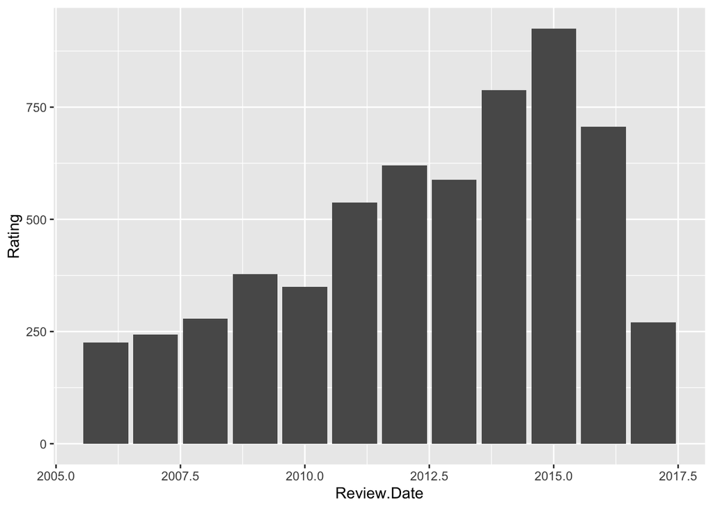

```r
ggplot(data = choco, aes(x=Review.Date , y=Rating)) +
  geom_bar(stat = 'identity')
```

## Question Set 2

For each of the questions below provide at least one graphic as a basis for your answer.

1. How are ratings distributed? Draw a histogram of ratings and describe it. Don’t forget to mention outliers, if there are any.

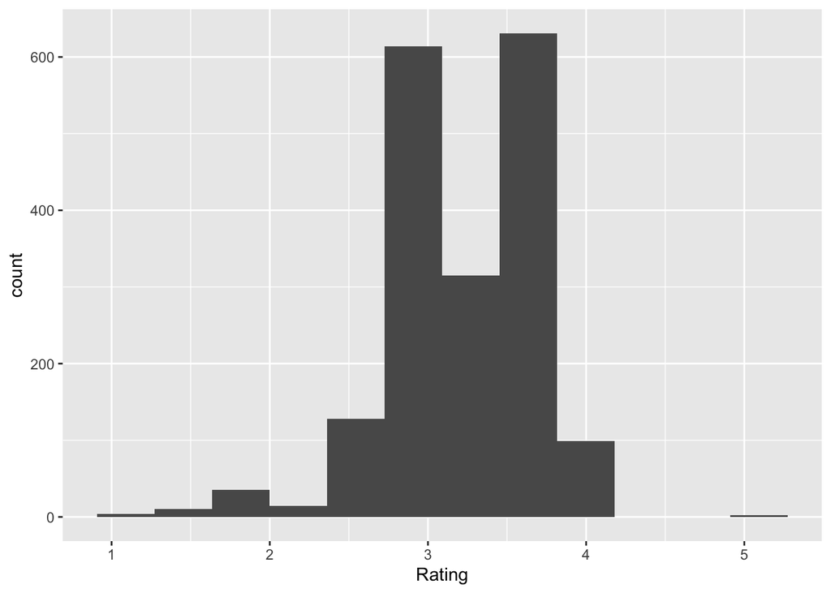

```r
ggplot(choco , aes(x = Rating)) + geom_histogram(bins = 12)
```

The ratings are the highest at around 2.75 and 3.75. The outlier seems to be the rating 5.

2. Do ratings depend on the cocoa percentage of a chocolate bar?

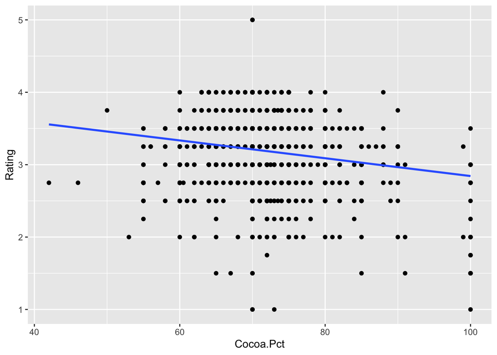

```r
ggplot(data =choco ,aes(x = Cocoa.Pct , y= Rating)) + geom_point() + geom_smooth(method=lm, se=FALSE)
```

3. How do ratings compare across different company locations? Focus on the three locations with the most ratings:

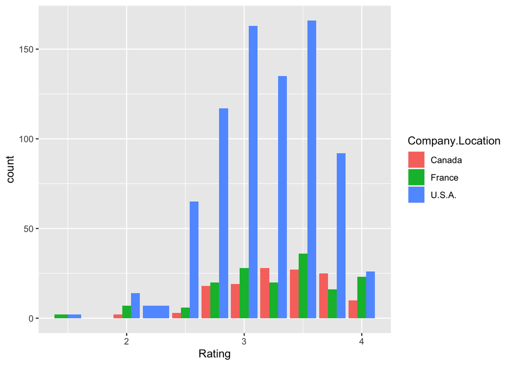

```r
fChoco<-dplyr :: filter (choco, Company.Location %in% c("U.S.A.", "France","Canada"))
ggplot(data =fChoco ,aes(x=Rating,fill= Company.Location)) +geom_bar(position = "dodge")
```